# INSYDE: a synthetic, probabilistic flood damage model based on explicit cost analysis

Francesco Dottori

European Commission, Joint Research Centre, Ispra, Italy

Rui Figueiredo

Scuola Universitaria Superiore IUSS Pavia, Pavia, Italy

Mario L. V. Martina

Scuola Universitaria Superiore IUSS Pavia, Pavia, Italy

Daniela Molinari

Dipartimento di Ingegneria Civile e Ambientale, Politecnico di Milano, Milano, Italy

Anna Rita Scorzini

Dipartimento di Ingegneria Civile, Edile-Architettura e Ambientale, Università degli Studi dell’Aquila, L’Aquila, Italy

02 Dec 2016

Abstract

Methodologies to estimate economic flood damages are increasingly important for flood risk assessment and management. In this work, we present a new synthetic flood damage model based on a component-by-component analysis of physical damage to buildings. The damage functions are designed using an expert-based approach with the support of existing scientific and technical literature, loss adjustment studies, and damage surveys carried out for past flood events in Italy. The model structure is designed to be transparent and flexible, and therefore it can be applied in different geographical contexts and adapted to the actual knowledge of hazard and vulnerability variables.

# Introduction

Flood damage evaluation today is a crucial component of any strategy for flood risk mitigation and management . In particular, models and methodologies for estimating economic damages are key for evaluating and comparing flood mitigation measures and for defining flood risk management plans.

Synthetic models adopt a conceptual expert-based approach using hypotheses and assumptions about damage mechanisms (what-if analysis). Synthetic damage models can be employed for a variety of applications , such as the derivation of damage functions for different types of assets, post-event damage estimation, and analysis of uncertainty sources in damage assessments.

Still, subjectivity in what-if analyses may result in uncertain damage estimates . In addition, these models are often affected by a lack of transparency, which limits their applicability and transferability, as well as possible improvements . Indeed, in many cases the rationale behind model development (e.g. assumptions, mechanisms considered, built-in parameters) is not clearly presented and relevant variables to be used are not well explained.

In this paper we propose a probabilistic methodology to derive synthetic damage curves for residential buildings called INSYDE (In-depth Synthetic Model for Flood Damage Estimation). The method is based on an explicit component-by-component analysis of physical damages to buildings, which takes into account available knowledge on damage mechanisms. INSYDE is transparent and can be applied in different contexts. Implemented functions and values are clearly explained so that they can be totally or partly modified according to the physical context in which the model is applied. Conversely, the methodology allows for different levels of detail in the analysis, hence the damage model can be adapted to the actual knowledge of relevant hazard and vulnerability variables.

The damage functions composing the model have been designed using an expert-based approach with the support of existing scientific and technical literature, loss adjustment studies, and damage surveys carried out for past flood events in Italy. It is important to note that the current version presented in this paper is limited to residential building damage estimation. The general methodology, however, can be extended to other types of assets, such as commercial or industrial buildings.

# Model description

INSYDE adopts a synthetic approach consisting of the simulated, step-by-step inundation of residential buildings, and in the evaluation of the corresponding damage based on building and hazard features. Such a methodology can also be referred to as a what-if analysis.

Damages are first modelled on a component-by-component basis using physically based mathematical functions and are then converted into monetary terms using full replacement costs derived from reference price lists. The overall economic damage to each building is obtained by summing each of the different damage components clean-up and removal costs, structural damage, non-structural damage, damage to finishing elements, damage to windows and doors, and damage to building systems.

For each subcomponent, a mathematical function describing the damage mechanism and associated cost is formulated, considering expert-based knowledge as well as available technical and scientific documentation. The general formulation can be described as follows: event features include all the physical variables describing the flood event at the building location, e.g. maximum external and internal water depth, flood duration, water quality (presence of contaminants) and sediment load. Building characteristics include all the variables that describe features and geometry of the building. Building features affect damage estimation either by modifying the functions describing damage mechanisms (e.g. system distribution, building structure) or by affecting the unit prices of the building components by a certain factor (e.g. building type, finishing level). Conversely, the geometrical properties of the building (e.g. footprint area, number of floors) are used in the estimation of the extension of damage to each of the building components. Unit prices refer to the cost of replacement or reparation of the building components per unit of measure (e.g. door removal cost per square metre, pavement replacement cost per square metre). The cost for each subcomponent is determined by the unit price (up) and the extension (ext). The latter is the measure of the physical dimension of the damage (e.g. m2 of plaster damaged) and depends on the event features and building characteristics.

This distinction is useful for model generalization. The extension of the damage is determined only by the physical effects that the flood event causes to the building; therefore, the same approach can be applied in different countries or geographic areas, provided that the local characteristics of the buildings are accounted for. Unit prices, instead, vary from country to country or even within a country, they can also be referred to standard or default unit prices in official publications. Therefore, local price values are well identified and can be easily replaced with more suitable ones in this approach.

Tables 1 and 2 describe in detail the event features and building characteristics parameters, their unit of measurement, their range, and the default values in case no informa- tion is supplied to the model. The variables listed in Tables 1 and 2 can directly affect damage estimation in terms of extension or indirectly by influencing other variables. An example of the latter case is YY (year of construction), which has no direct impact on the damage mechanisms of the different building subcomponents but indirectly influences the selection of other variables such as PD (heating system distribution) and PT (heating system type). Another example is NF (number of floors), which only directly affects soil consolidation despite indirectly influencing many other building components because damage on upper floors can only occur if the floors actually exist in the building. The number of flooded floors is then calculated as a function of inundation depth and interfloor height of the building (IH).

It is important to underline that during the model design, observed damage data were essentially used to analyse the relations between hazard parameters and damage mechanisms in order to improve physical damage functions. For instance, the functions for structural damage found in literature were implemented in the model after some modifications, as they were not in line with the observed damages. Such a usage is consistent with an expert-based approach because observed data were first interpreted and then used to modify parts of the model structure rather than applied to calibrate the parameters of existing functions.

Figure 1 provides an example of damage functions developed for a default building in the case of a flood with a duration = 24 h, flow velocity = 0.5 m/s, sediment concentration = 0.05, and presence of pollutants (water quality = 1).

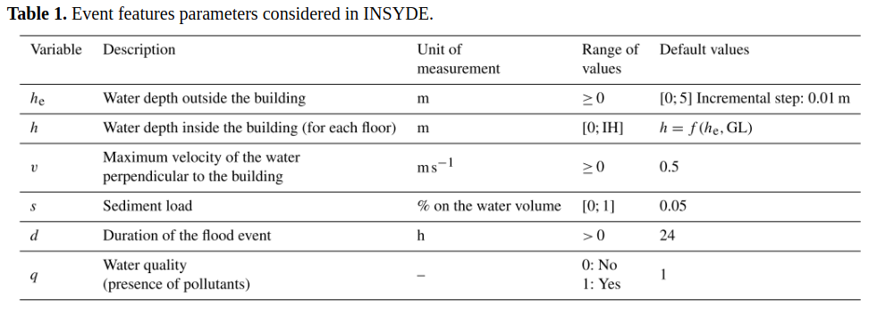

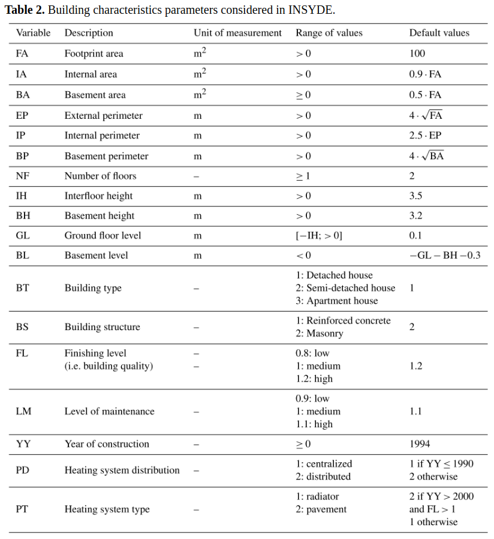

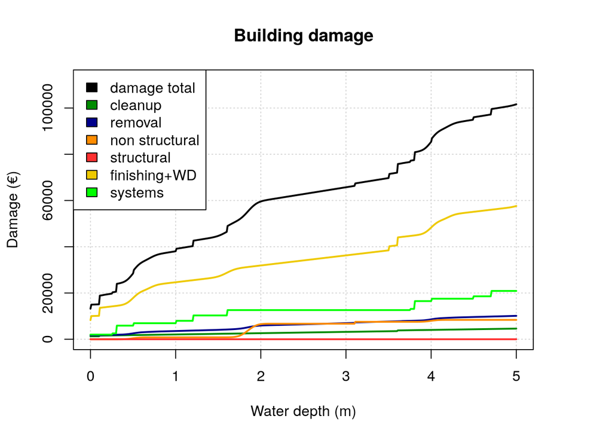

**Figure 1:** Example of INSYDE damage functions considering the following event variables: flow velocity = 0.5 m/s , flood duration = 24 h, sediment concentration = 0.05, and water quality = presence of pollutants (1=yes, 0=no). Damage functions for entire building and different building components.